# Delta Hubs and Flights Patterns

Kaiyang Yao, Yixiao Wang

12/19/2020

# 1. Introduction and Background

[figure not shown]

Delta Air Lines (Delta), a member of the SkyTeam alliance, is one of the major airlines of the United States. Just like its red “upward” delta logo shows, the company applies the slogan “Keep Climbing” and provides high-quality services to the passengers. Delta has several major airline hubs located in the U.S., with Atlanta (ATL) being its largest in terms of total passengers and number of departures. In this project, we found the 4 most important domestic hubs of Delta airlines and made a comparative analysis among them through the data collected from the U.S. Department of Transportation.

# 2. Data Collection

We downloaded the public data from Kaggle. The data contains the U.S. commercial aviation industry metrics including monthly passengers, flights, seat-miles, and revenue-miles from 2002 to 2017. It covers 30 major airports in the U.S., but without their location coordinates. We then found a separate public data set for airport locations on Humanitarian Data Exchange website and combined them together. This combined data allows us to draw the airports on a leaflet map.

After that, we extracted the data specific to Delta airlines. The data contains the industry metrics of Delta airlines at each airport. We will use this data to do the further analysis.

# 3. Analysis

## 3.1 Which 4 hubs

| Airports | Total Domestic Flights | Rank |
| --- | --- | --- |
| ATL | 2809660 | 1 |
| SLC | 483706 | 2 |
| MSP | 448949 | 3 |
| DTW | 402221 | 4 |
| LGA | 321640 | 5 |
| JFK | 271348 | 6 |
| LAX | 268234 | 7 |
| MCO | 228961 | 8 |
| BOS | 210761 | 9 |
| FLL | 154987 | 10 |

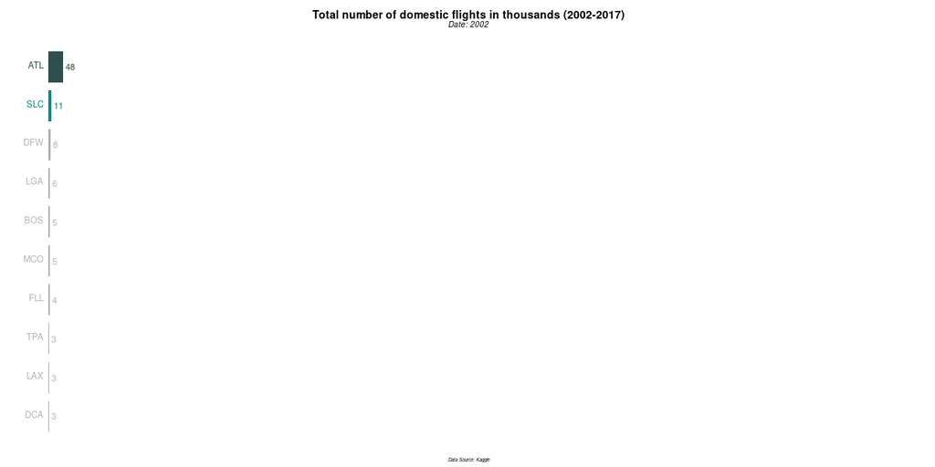

## 3.2 Delta hub route map visualization

Based on the result above, we marked the total of 30 airports on a leaflet map and changed the icon for the 4 hubs to a delta logo. The name of each airport will pop up when the mouse hovers on the icon.

[interactive chart not shown]

Geographically speaking, these 4 hubs are balanced and complimentary, which together play a key role in Delta’s national and global route operations. Hartsfield-Jackson Atlanta (ATL), the world’s largest hub, is primarily dominated by Delta, with 71% of the market share. In the year 2016, Delta carried three million passengers from ATL to destinations all around the world every single month. Salt Lake City (SLC) is Delta’s second-largest hub, with 54% of the market share. The airport is a major gateway to the west coast and gives a new choice to passengers from the east. Minneapolis - Saint Paul (MSP) and Detroit Metropolitan (DTW) are Delta’s Midwest gateways and connecting hubs, which can also reduce the stress from its two other hubs.

Then we summarized the routes from these 4 hubs airports to other 30 major airports on the map above. In the next visualization, each curve represents that there is at least one flight operated by Delta between that two airports.

[interactive chart not shown]

The result is not surprising. It is clear that almost all other major airports are connected by the 4 Delta hubs, with very few exceptions.

## 3.3 Comparing 4 hubs

First of all, we plotted the total number of domestic flights of the 4 hubs. The graph shows that MSP and DTW were not core hubs until 2010. ATL is of most importance. And SLC has relatively fewer flights. Also, the frequent small fluctuated pattern is shown on the graph, which can be interpreted as the changes between low and high seasons for traveling. During slack seasons, fewer people travel and fewer flights are operated, and vice versa.

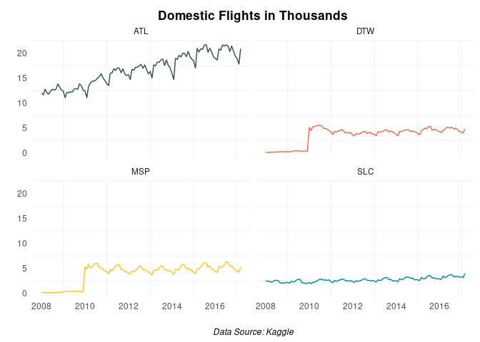

We then plotted the proportion of domestic flights to all flights. Domestic flights of ATL and DTW account for a relatively low proportion, while domestic flights of SLC account for a relatively high proportion. In addition, the proportion of DTW and SLC in the four airports shows an overall trend of decline, while the proportion of MSP and ATL are gradually increasing.

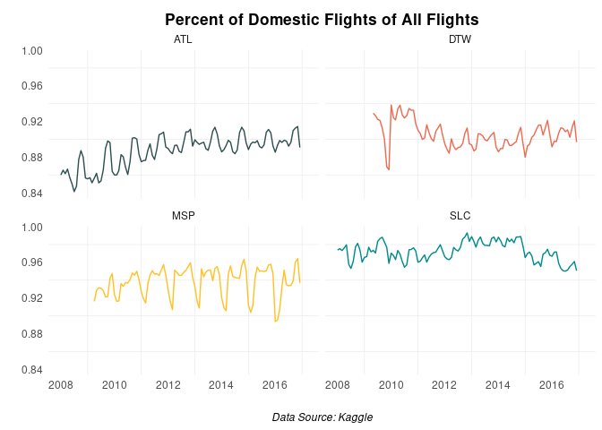

From the two sets of graph above, we can clearly see that the proportion of domestic flight and the total number of domestic flights have several similar cyclical fluctuations, especially for ATL and MSP. In order to further explore this phenomenon, we selected ATL, which has a large amount of data for analysis.

To compare the patterns of those two types of graphs, we normalized the total number of domestic flights each month to proportion by the formula $0.8 + 0.2 \times$ *(domestic flights that month)* / *(maximum domestic flights that year)*. Here 0.8 is a constant to separate the two lines.

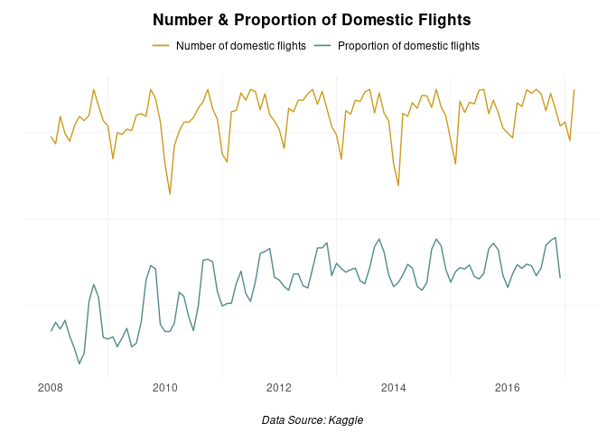

The golden line represents the number of domestic flights (in proportion) and the dark blue line represents the proportion of domestic flights to all flights. Based on the graph, each line has a peak value and a valley value over a period of time. The annual changes of the two lines are basically the same, so we selected 2015-2017 as the representative.

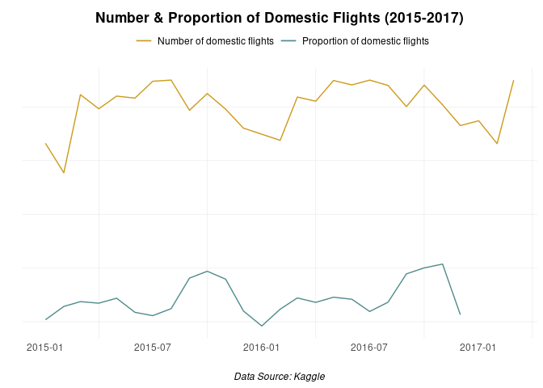

For the golden line, the total number of domestic flights, there is a trough from January to February every year, and a high stage from April to October every year, especially in July and August. For the dark blue line, the percentage of domestic flights, there’s a trough in July, a peak in October, and then there is a trough around January again every year.

Taken together, there are three key time periods each year. In January, the number of domestic flights is low and the proportion of domestic flights is low; In July, the number of domestic flights is high and the proportion of domestic flights is low; In October, the number of domestic flights is high, and the proportion of domestic flights is high.

The first period (January) indicates a slack season for air travel in the U.S. compared with abroad. Judging by the scale of the slump, there may be also a slack season for air travel abroad. July is the second period, at this time, the number of domestic flights increases and the proportion of domestic flights decreases, indicating that there are a large number of international flights. Our guess is that this is the result of the increasing foreign travelers. People are more likely to come to the U.S. at summer time for traveling, which makes sense because summer season is often warm and beautiful. The third period is October. The number of domestic flights remains high in October, but the proportion of domestic flights increases accordingly. This suggests that the peak season for international traveling is fading, and the proportion of domestic flights dominates.

# 4. Conclusion

In this project, we came up with the four hubs by ranking Delta’s total number of domestic flights at each major airport. We first made a basic analysis based on their location and the flight routes geographically. Then we compared the industry metrics among these 4 hubs, including the number of domestic flights and the proportion of domestic flights. Later, based on the findings we conducted a flight pattern analysis using ATL airport. The result shows that there are three key periods in the yearly cyclical traveling pattern.